# Project Report

Caroline Andy, Vasili Fokaidis, Stella Li, Tessa Senders, Lily Wang

12/11/2020

## Abstract

**Background:** Hate crimes are currently the highest priority of the FBI’s civil rights program. Existing research suggests that various community-level socioeconomic factors, such as income inequality, are associated with hate crime rate.

**Objectives:**  
We aimed to analyze the association between community-level variables and state-level hate crime rates using data reported to the Southern Poverty Law Center and analyzed in a 2017 FiveThrityEight article.

**Methods:**  
The data used for this project included state-level hate crime rates per 100,000 individuals in the population, as reported by the Southern Poverty Law Center during the first weeks of November, 2016. Data elements also included socioeconomic factors that are hypothesized to be associated with hate crime.

The association between these socioeconomic factors and the hate crime rate outcome were examined using multivariable linear regression analysis. The outcome variable was first log transformed to adhere to the linear regression assumption of normal distribution. After identifying the significant predictors of state-level hate crime rate when controlling for all other covariates, we used automated and criterion-based approaches to generate a parsimonious high-performing predictive model. Multicollinearity of covariates and variable interaction were also tested for and considered in model development.

**Results:**  
Gini Index (an indicator of wealth inequality) and percent population with a high school degree were both significant predictors of state-level hate crime rate when controlling for all other covariates.

Of the continuous variables, percent non-citizen and percent non-white were found to have a correlation coefficient of 0.753; median household income and percentage of population with a HS degree had a correlation coefficient of 0.651, both of which may suggest multicollinearity. No statistically significant interactions were identified between any variables in regression modeling.

**Conclusions:**  
Based on the November 2016 Southern Poverty Law Center data, Gini Index (an indicator of wealth inequality) and percent population with a high school degree were both significantly and independently associated of state-level hate crime rate.

## Introduction

For this project, we used this dataset to critically analyze this research team’s findings to identify state-level variables associated with rates of hate crimes, and to generate a high performing predictive model for population-adjusted hate incidents in the United States.

## Methods

### Data Exploration

The data used for this project included state-level hate crime rates (hate crimes per 100,000 population), as reported by the Southern Poverty Law Center during the first weeks of November, 2016. Collected state-level demographic variables include:

- Unemployment rate (high vs low) (as of 2016)
- Urbanization (high vs low) (as of 2015)
- Median household income (as of 2016)
- Percent of residents with a high school degree (as of 2009)
- Percent of residents who are non-citizens (as of 2015)
- Income Gini coefficient (a measure of the extent to which the distribution of income among individuals within an economy deviates from a perfectly equal distribution; as of 2015)
- Percent of residents who are non-White (as of 2015)

Using these data, our goal was to construct our own multivariable linear regression model to assess which of the collected variables, if any, are significantly associated with population-adjusted hate incidents in the United States, to altogether critically examine the article’s findings. To do so, we first generated descriptive statistics and plotted the distribution of the outcome (population-adjusted hate incidents per 100,000 population) to determine whether any data transformations would be necessary, and to assess whether any outliers exist within the data.

To further elucidate the existence of outliers/influential points, we visualized the hate crime rate by state, and generated residuals vs fitted, normal Q-Q, scale-location, and residuals vs leverage plots. Any states that were deemed to be an outlier were included in subsequent analyses, but the same analyses were also run a second time on the dataset excluding the outliers for comparison.

To report basic descriptive statistics, we generated a table which includes the mean, median, range (min-max), interquartile range, and count of missing entries for each numeric variable, and category percent breakdowns and count of missing entries for categorical variables (Table 1).

#### Multicollinearity and Interactions

In order to investigate the existence of multicollinearity between each of the continuous variables, we generated a correlation matrix. We decided that any correlation coefficient of 0.6 and above may suggest multicollinearity; thus, in these instances, at least one of those correlated variables were dropped during subsequent model development. Furthermore, we calculated the variance inflation factors (VIFs) for all variables, which quantify the degree of multicollinearity between the given predictor all other remaining covariates.

Next, we tested for significant interactions between each of the two categorical variables, unemployment and urbanization, and all other continuous variables. Any variables with significant interactions were then stratified and analyzed again.

#### Model Development and Validation

To generate a high performing predictive model, we then performed two automated procedures for model variable selection (forward and backward selection) and several criterion based approaches (CP, r-squared and SSE/RSS). We also ran an analysis of variance (ANOVA) test to identify the most optimal model subset.

Using these results, we then identified a model which maximizes parsimony, predictive performance, interpretability and practical application, which takes into account variables deemed to be significant and practically important in existing literature.

Model goodness of fit was also assessed on a dataset excluding Washington DC, a previously noted outlier.

For validation, we performed 5-fold Cross Validation to check the performance of our two models. One model included the covariates gini_index, perc_pop_hs, and unemployment and the other model included just gini_index and perc_pop_hs. We performed 5-fold Cross Validation of both models including the entry “District of Columbia” and excluding the entry “District fo Columbia” to see if the outlier impacted our results.

## Results

#### Data Exploration

To visualize the distribution of the hate crimes rate data, we first generated an overlaid density and histogram plot (Figure 1). Multivariable linear regression modeling operates under several assumptions, which include residual homoscedasticity (constant variance) and normality. Initial exploration of the distribution of the hate crimes rate data showed a strong departure from standard normal distribution with significant right skewness. Thus, we performed a Box Cox test to isolate the ‘best’ power transformation on the hate crimes rate variable to achieve normal residuals.

The generated Box Cox plot results suggest that a logarithmic transformation of the hate crimes rate data would most closely approximate normal distribution (Figure 2). Thus, we operated moving forward in model development using the log hate crimes rate as the outcome of interest.

To investigate for any outliers in the data, we then plotted the hate crimes rate by state, and generated residuals vs fitted, normal Q-Q, scale-location, and residuals vs leverage plots (Figures 3-7). As Washington DC is clearly outside of the Cook’s distance line in the residuals vs leverage plot, we concluded that this point is an outlier. This data point was included in any subsequent analyses, though all analyses were also rerun on this dataset excluding Washington DC for comparison.

A table of basic descriptive statistics for the collected socioeconomic variables is included in the appendix (Table 1).

#### Multicollinearity and Interactions

Out of the continuous variables, percent non-citizen and percent non-white has a correlation coefficient of 0.753, median household income and percentage of population with a HS degree has a correlation coefficient of 0.651, both of which may suggest multicollinearity. All other correlation coefficients do not suggest multi-collinearity (Table 2).

Use of variance inflation factors (VIFs) showed that the percent population without a high school degree (3.895), percent non-citizen (3.728), percent non-white (3.236) and median household income (3.108) had the highest degrees of multicollinearity between all other predictors. These values approach but do not exceed 4, the generally accepted value which denotes the need for further investigation and/or consideration of multicollinearity corrections.

#### Model Development and Validation

We began our regression analyses by running linear regression models containing all possible predictors for both the untransformed hate crime rate and the log hate crime rate. Our results support the conclusions drawn in the FiveThirtyEight article: that the Gini Index was the most significant independent predictor of state hate crime rate when controlling for all other covariates; percent high school graduates variables was the only other statistically and independently significant variable.

We also isolated the top two best performing models per number of predictors using the adjusted R squared criterion. We then generated a plot of the distribution of the adjusted R squared statistic for the top performing model for each number of included predictors (Figure 9). Results show that the model with three predictors performed the best while maximizing parsimony.

To help distinguish the most optimal model between one with three predictors (Gini Index, percent high school graduates, and unemployment), and one with two (Gini Index and percent high school graduates), we ran an analysis of variance (ANOVA) test. Results suggest that the model containing two parameters is most optimal. The adjusted R-squared of the two-predictor model was 0.2541, while that of the three-predictor model was 0.2571, which is not a large enough increase in proportion of variance explained to justify keeping unemployment in the model.

Through cross-validation, we determined that the aforementioned two-predictor model also had better predictive value (RMSE = 0.5949, MAE = 0.5050) than the three-predictor model (RMSE = 0.6038, MAE = 0.5067) (Figure 11).

Finally, because Washington DC was deemed to be an outlier previously, we re-ran our final model excluding it. Gini index became an insignificant predictor and adjusted R-squared of the total model decreased as well (from 0.2541 to 0.1185). However, predictive value increased (RMSE = 0.5554, MAE = 0.4741).

## Discussion/Conclusion

The drastic changes in predictor significance and adjusted R-squared between the model including and excluding Washington DC suggest that the district is indeed an influential point. The district has the highest hate crime rate and the highest income inequality out of all the states.

## Figures and Tables

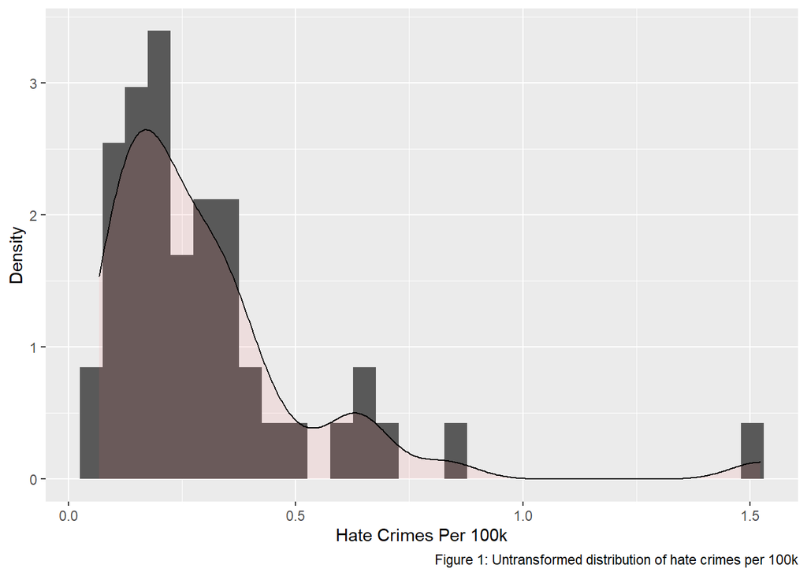

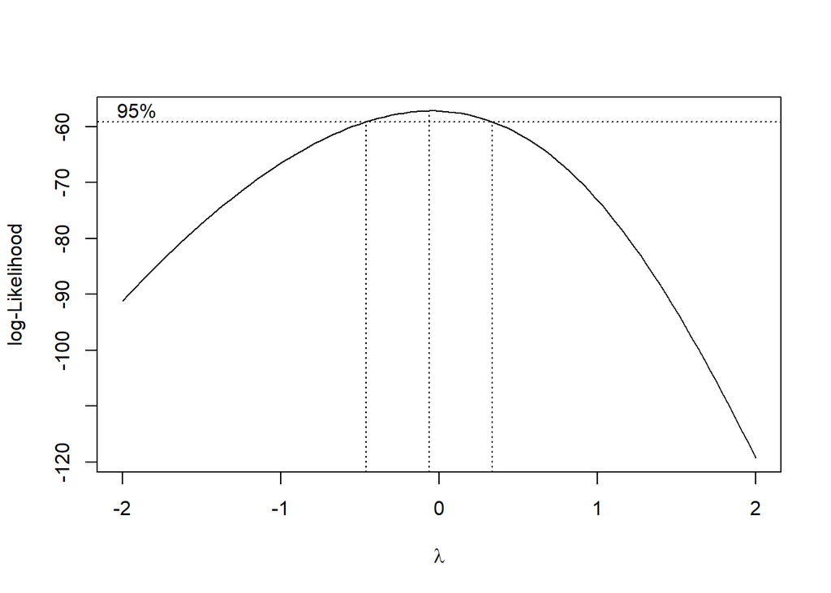

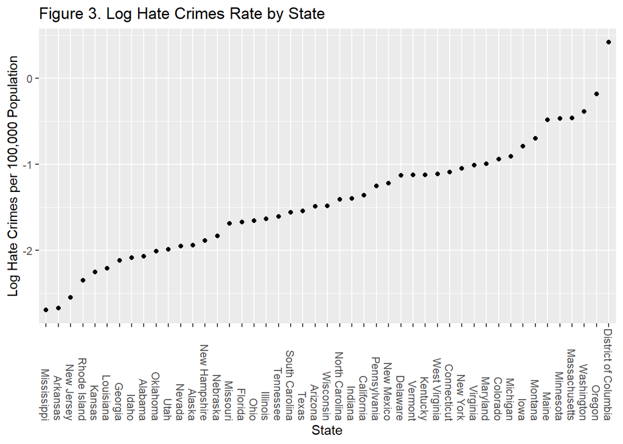

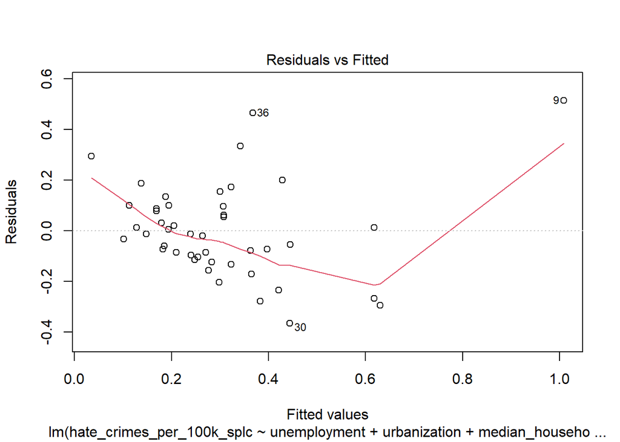

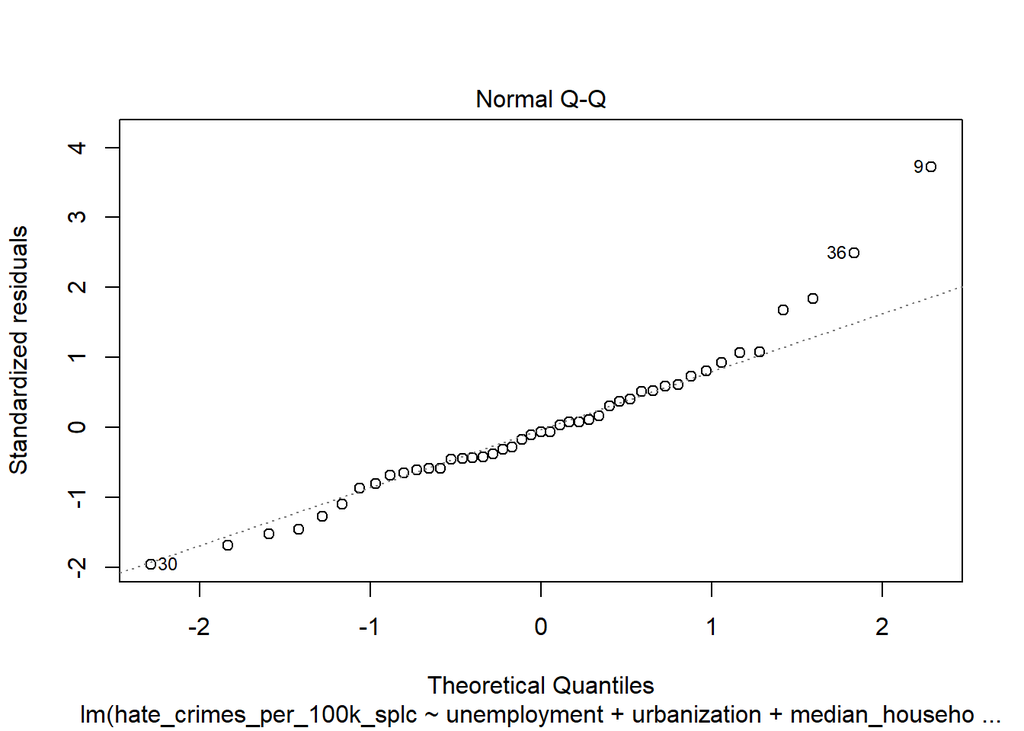

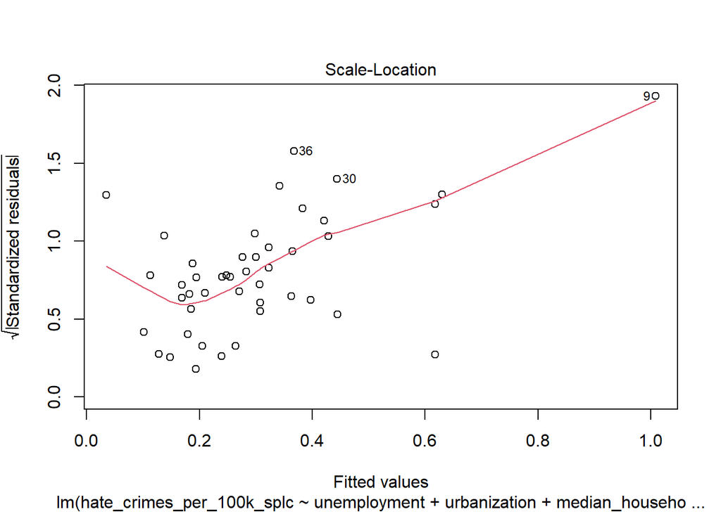

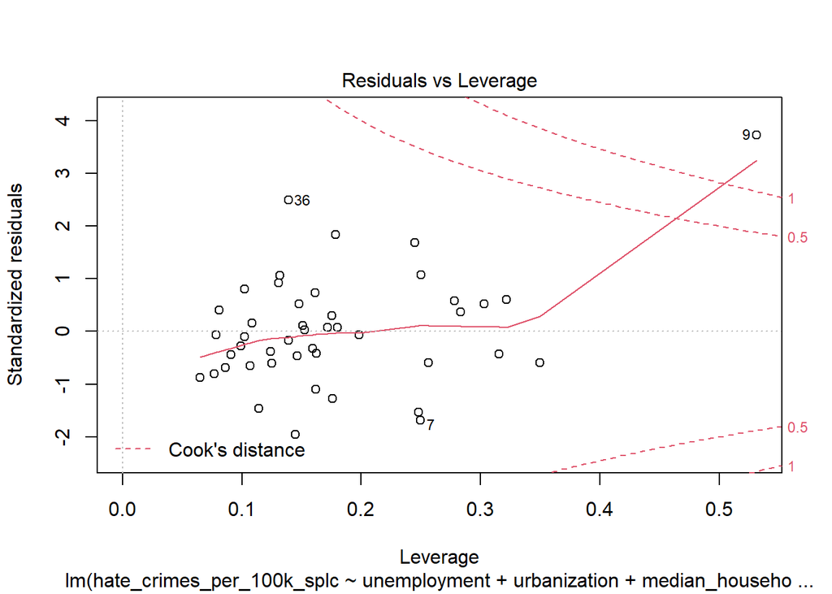

Table 1: Descriptive Statistics of Tidied Dataset

|  | Overall (N=47) |
| --- | --- |
| **Unemployment** |  |
| high | 24 (51.1%) |
| low | 23 (48.9%) |
| Missing | 0 |
| **Urbanization** |  |
| low | 23 (48.9%) |
| high | 24 (51.1%) |
| Missing | 0 |
| **Median Household Income** |  |
| Mean (SD) | 54802.298 (9255.117) |
| Median (Q1, Q3) | 54310.000 (47629.500, 60597.500) |
| Min - Max | 35521.000 - 76165.000 |
| Missing | 0 |
| **% Adults >25yrs With HS Degree** |  |
| Mean (SD) | 0.866 (0.034) |
| Median (Q1, Q3) | 0.871 (0.839, 0.895) |
| Min - Max | 0.799 - 0.915 |
| Missing | 0 |
| **% of Population Not U.S. Citizens** |  |
| Mean (SD) | 0.055 (0.031) |
| Median (Q1, Q3) | 0.050 (0.030, 0.080) |
| Min - Max | 0.010 - 0.130 |
| Missing | 2 |
| **Gini Index** |  |
| Mean (SD) | 0.456 (0.021) |
| Median (Q1, Q3) | 0.455 (0.440, 0.468) |
| Min - Max | 0.419 - 0.532 |
| Missing | 0 |
| **% of Population Not White** |  |
| Mean (SD) | 0.315 (0.150) |
| Median (Q1, Q3) | 0.300 (0.205, 0.420) |
| Min - Max | 0.060 - 0.630 |
| Missing | 0 |
| **Hate Crime Rate Per 100k** |  |
| Mean (SD) | 0.304 (0.253) |
| Median (Q1, Q3) | 0.226 (0.143, 0.357) |
| Min - Max | 0.067 - 1.522 |
| Missing | 0 |
| **hate_crimes_log** |  |
| Mean (SD) | -1.429 (0.676) |
| Median (Q1, Q3) | -1.486 (-1.947, -1.030) |
| Min - Max | -2.696 - 0.420 |
| Missing | 0 |

```
##                           median_household_income perc_pop_hs perc_non_citizen
## median_household_income                     1.000       0.651            0.302
## perc_pop_hs                                 0.651       1.000           -0.262
## perc_non_citizen                            0.302      -0.262            1.000
## gini_index                                 -0.130      -0.537            0.480
## perc_non_white                              0.039      -0.496            0.753
## hate_crimes_per_100k_splc                   0.344       0.263            0.244
## hate_crimes_log                             0.311       0.296            0.137
##                           gini_index perc_non_white hate_crimes_per_100k_splc
## median_household_income       -0.130          0.039                     0.344
## perc_pop_hs                   -0.537         -0.496                     0.263
## perc_non_citizen               0.480          0.753                     0.244
## gini_index                     1.000          0.548                     0.381
## perc_non_white                 0.548          1.000                     0.111
## hate_crimes_per_100k_splc      0.381          0.111                     1.000
## hate_crimes_log                0.219         -0.007                     0.892
##                           hate_crimes_log
## median_household_income             0.311
## perc_pop_hs                         0.296
## perc_non_citizen                    0.137
## gini_index                          0.219
## perc_non_white                     -0.007
## hate_crimes_per_100k_splc           0.892
## hate_crimes_log                     1.000
```

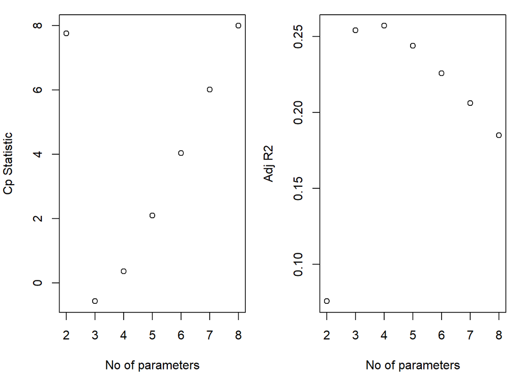

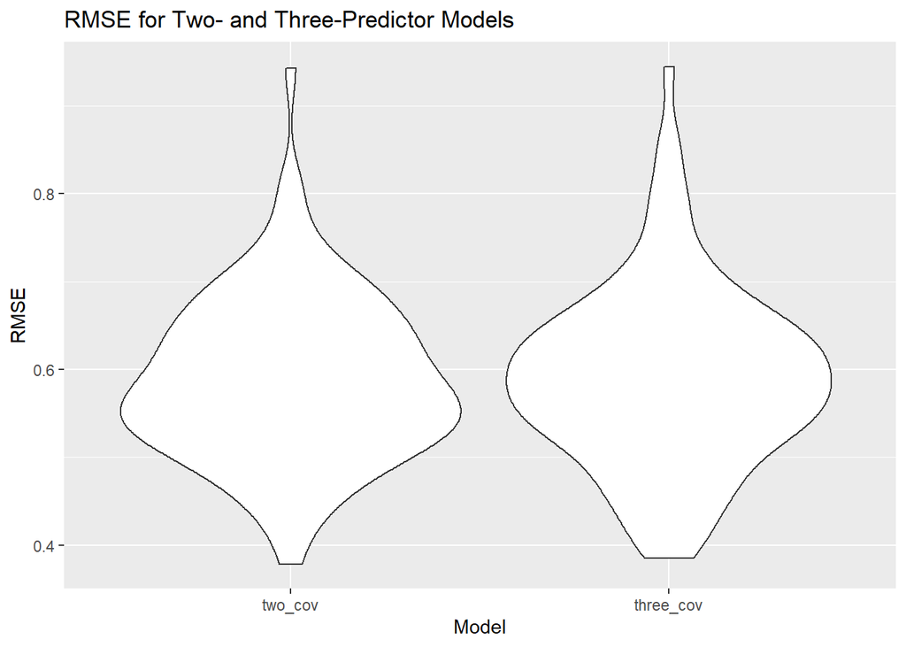